# STSCI 5030 - Fall 2018 - HW3 Q1

Harry Lu, dl947

Due Friday, October 12, 2018

This question is based on the data in `precipitation.csv` which gives average daily precipitation for two Canadian cities. There are three columns indicating:

- the day of year
- the city (0 = Whitehorse, 1 = Yellowknife)
- average precipitation between 1940 and 1990

# a

> Plot precipitation over time, indicating the city by different marks.

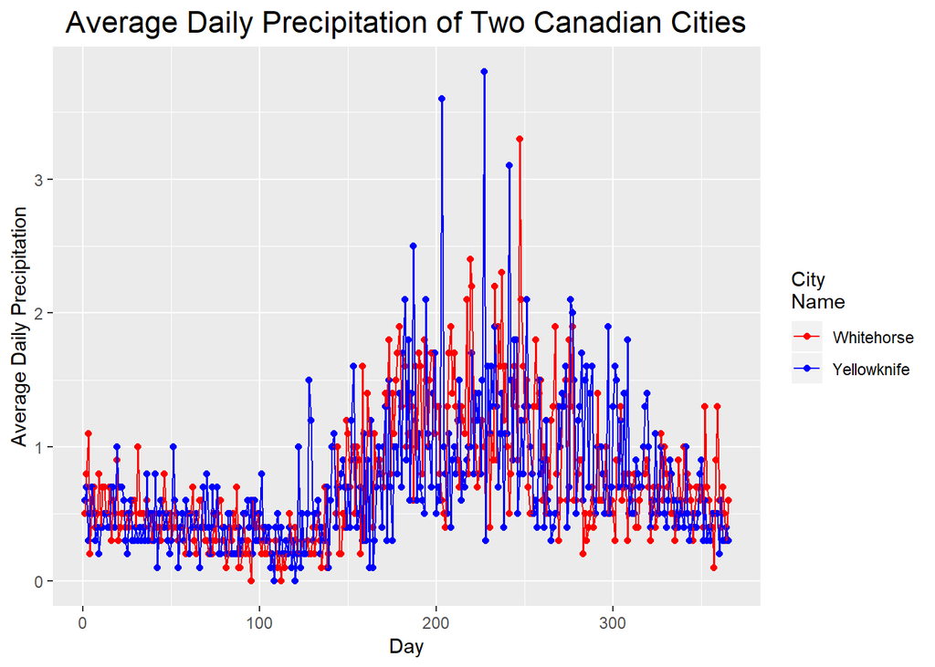

```r
library(ggplot2)
p=read.csv(file="https://raw.githubusercontent.com/HarryLu95/dalu/master/CU/5030/precipitation.csv",header=TRUE)
p$place=as.factor(p$place)
index=1:730
ggplot(data=p,aes(x=day,y=prec,color=place))+
  geom_point()+
  geom_line()+
  ggtitle("Average Daily Precipitation of Two Canadian Cities")+
  theme(plot.title=element_text(size=16,hjust=0.5))+
  xlab("Day")+
  ylab("Average Daily Precipitation")+
  scale_colour_manual(values=c("red", "blue"),
                    name="City\nName",
                    labels=c("Whitehorse","Yellowknife"))
```

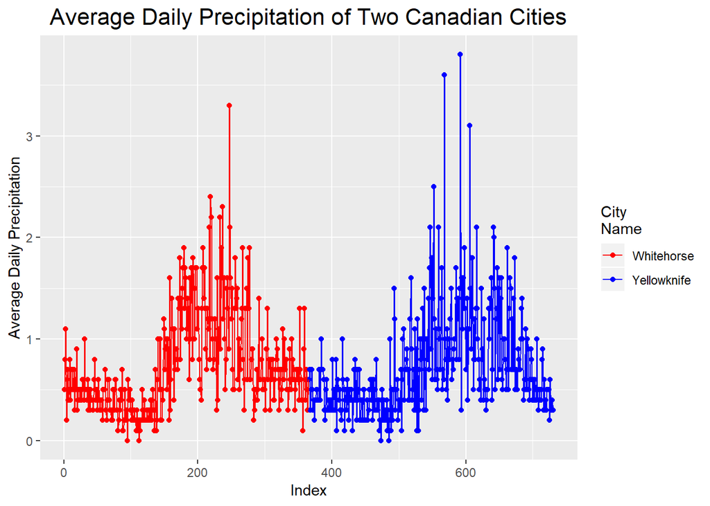

```r
ggplot(data=p,aes(x=index,y=prec,color=place))+
  geom_point()+
  geom_line()+
  ggtitle("Average Daily Precipitation of Two Canadian Cities")+
  theme(plot.title=element_text(size=16,hjust=0.5))+
  xlab("Index")+
  ylab("Average Daily Precipitation")+
  scale_colour_manual(values=c("red", "blue"),
                    name="City\nName",
                    labels=c("Whitehorse","Yellowknife"))
```

# b

> Comment on whether a linear model is appropriate here.

Neither two simple linear models nor a multiple linear model is appropriate here. First, there is a categorical variable in the data set, so that a multiple linear model is not valid. Second, if we treat the data set as two smaller data set by different city, each series of precipitation data is also affected by other unspecified factors such as season. In other words, two simple linear models are also not valid. Better models may be some time series model.

# c

> Form a matrix of linear spline bases in `d = day` with columns $[1,d,(d-100)_+,(d-200)_+,(d-300)_+]$ where $(d-100)_+$ is $\max(d-100,0)$. In `R` you can get this from `(d-100)*(d>100)` or `pmax(d-100,0)`. Plot the third column of this matrix.

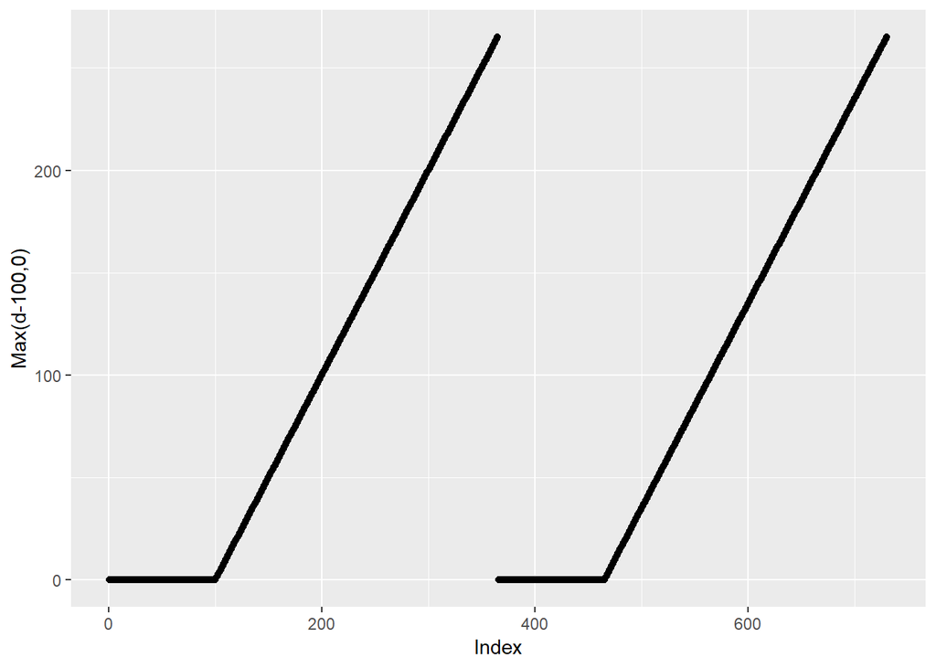

```r
x1=rep(1,times=730)
x2=p$day
x3=pmax(p$day-100,0)
x4=pmax(p$day-200,0)
x5=pmax(p$day-300,0)
X=cbind(x1,x2,x3,x4,x5)
Y=as.data.frame(cbind(index,x3))
ggplot(data=Y,aes(x=index,y=x3))+
  geom_point()+
  xlab("Index")+
  ylab("Max(d-100,0)")
```

# d

> Regress precipitation onto your basis in part c and plot the resulting function along with the data. i.e., plot the prediction for each day as a line through the data.

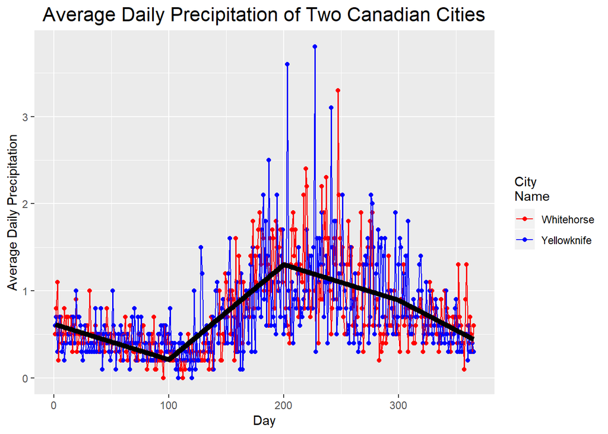

```r
a=X%*%solve(t(X)%*%X)%*%t(X)%*%p$prec
#plot(a,ylim=c(0,3.8));par(new=TRUE);plot(p$prec,ylim=c(0,3.8))
p_new=cbind(p,a)
ggplot(data=p_new,aes(x=day,y=prec,color=place))+
  geom_point()+
  geom_line()+
  ggtitle("Average Daily Precipitation of Two Canadian Cities")+
  theme(plot.title=element_text(size=16,hjust=0.5))+
  xlab("Day")+
  ylab("Average Daily Precipitation")+
  scale_colour_manual(values=c("red", "blue"),
                    name="City\nName",
                    labels=c("Whitehorse","Yellowknife"))+
  geom_line(aes(x=day,y=a),colour="black",size=2)
```

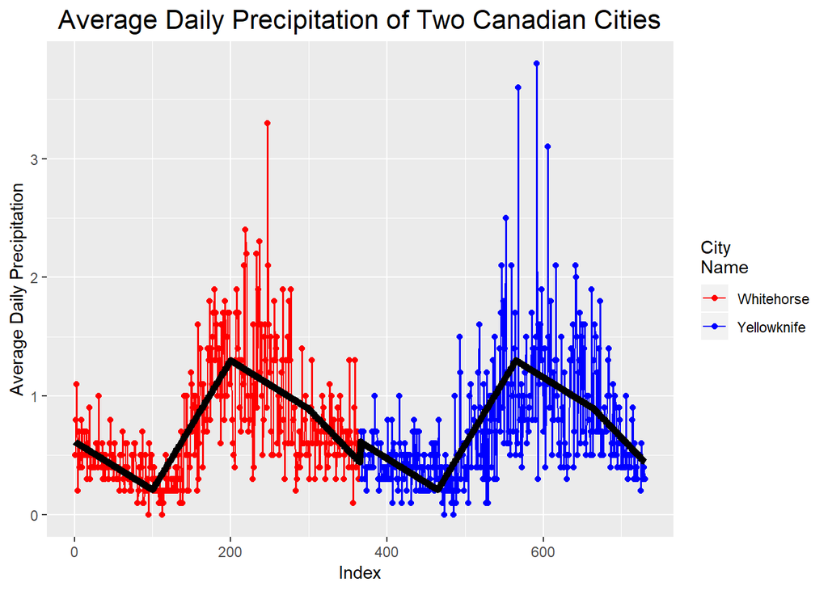

```r
ggplot(data=p_new,aes(x=index,y=prec,color=place))+
  geom_point()+
  geom_line()+
  ggtitle("Average Daily Precipitation of Two Canadian Cities")+
  theme(plot.title=element_text(size=16,hjust=0.5))+
  xlab("Index")+
  ylab("Average Daily Precipitation")+
  scale_colour_manual(values=c("red", "blue"),
                    name="City\nName",
                    labels=c("Whitehorse","Yellowknife"))+
  geom_line(aes(x=index,y=a),colour="black",size=2)
```

# e

> Obtain a design matrix to allow you to plot different precipitation curves for each city with one model. Produce these plots.

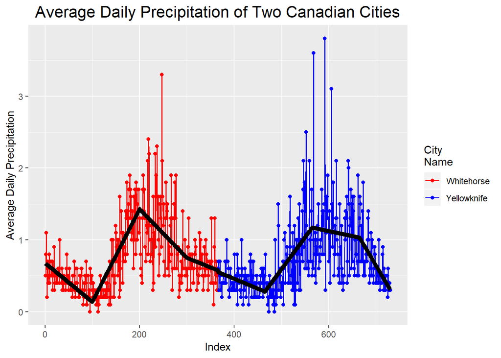

```r
Y=X[1:365,]
a0=Y%*%solve(t(Y)%*%Y)%*%t(Y)%*%p$prec[1:365]
a1=Y%*%solve(t(Y)%*%Y)%*%t(Y)%*%p$prec[366:730]
a01=c(a0,a1)
p_newnew=cbind(p,a01)
ggplot(data=p_newnew,aes(x=index,y=prec,color=place))+
  geom_point()+
  geom_line()+
  ggtitle("Average Daily Precipitation of Two Canadian Cities")+
  theme(plot.title=element_text(size=16,hjust=0.5))+
  xlab("Index")+
  ylab("Average Daily Precipitation")+
  scale_colour_manual(values=c("red", "blue"),
                    name="City\nName",
                    labels=c("Whitehorse","Yellowknife"))+
  geom_line(aes(x=index,y=a01),colour="black",size=2)
```